# Introduction

Les séismes sont des événements naturels dévastateurs qui peuvent causer d’importants dégâts matériels et humains. Prédire les dégâts potentiels d’un séisme est d’une importance capitale pour la gestion des risques, la planification d’urgence et la réduction des impacts sur les communautés. Pour réaliser ces prédictions, nous disposons de données précieuses, telles que le pays où le séisme se produit, sa magnitude (exprimée en échelle de Richter) et sa profondeur.

Cependant, la prédiction des dégâts des séismes n’est pas une tâche simple, car de nombreux facteurs interviennent. C’est là qu’intervient l’algorithme *Random Forest*!

# 1. Algorithme Random Forest

Le Random Forest est un algorithme d’apprentissage automatique appartenant à la catégorie des méthodes d’ensemble. Il est utilisé pour résoudre des problèmes de classification et de régression

## 1.1 Traitement des données

Avant d’utliser l’algorithme *Random Forest* nous devons préparer nos données.

Tout d’abord, nous devons diviser notre jeux de données en deux (70% pour l’entraînement, 30% pour les tests).

```r
# Définir le taux de division (70% pour l'entraînement, 30% pour les tests)
train_proportion <- 0.7

# Créer l'ensemble de données d'entraînement et de test
set.seed(123)  # Pour la reproductibilité
splitIndex <- createDataPartition(dat$impact.significance, p = train_proportion, list = FALSE)
train_data <- dat[splitIndex, ]
test_data <- dat[-splitIndex, ]
```

Ensuite, on utlise le modèle d’encodage *one-hot* pour encoder nos données relatives à la loacalisation des séismes…

```r
# Création du modèle d'encodage one-hot
dummy_model_train <- dummyVars(~ location.country, data = train_data)
dummy_model_test <- dummyVars(~ location.country, data = test_data)

# Transformation des données d'entraînement
train_data_encoded <- predict(dummy_model_train, newdata = train_data)
test_data_encoded <- predict(dummy_model_test, newdata = test_data)
```

Enfin, on standardise nos variables impact.magnitude et impact.profondeur pour que leur ordre de grandeur soit comparable.

```r
# Standardisation (z-score) des variables
train_data$impact.depth_standardisee <- (train_data$location.depth - mean_depth) / sd_depth
train_data$impact.magnitude_standardisee <- ((train_data$impact.magnitude - mean_magnitude) /
  sd_magnitude)
test_data$impact.depth_standardisee <- (test_data$location.depth - mean_depth) / sd_depth
test_data$impact.magnitude_standardisee <- ((test_data$impact.magnitude - mean_magnitude) / sd_magnitude)
```

## 1.2 Modelisation et prediction

Pour développer notre modèle, nous avons utilisé la fonction randomForest() du package RandomForest de R. Ici nous essayons d’expliquer les dégats d’un séisme (impact.significance) en fonction de la profondeur (impact.depth), la magnitude (impact.magnitude) et la localisation (data frame qui contient nos données location.country encodées).

```r
rf_model <- randomForest(impact.significance ~ impact.depth_standardisee + impact.magnitude_standardisee + ., data = train_data_encoded_common)
```

On prédit les dégats de nos séismes qui sont dans la base de test (tast_data).

```r
predictions <- predict(rf_model, newdata = test_data_encoded_common)
```

Une des méthodes pour comparer nos prédictions et nos valeurs réelles est de calculer le RMSE, ici on a,

```
## erreur quadratique moyenne :  21.69296
```

# 1.3 Visualisation

Le meilleur moyen de visualiser nos prédictions est un graphe de type fitted vs true. L’idée est de comparer les données prédites et réelles sur un même graphique.

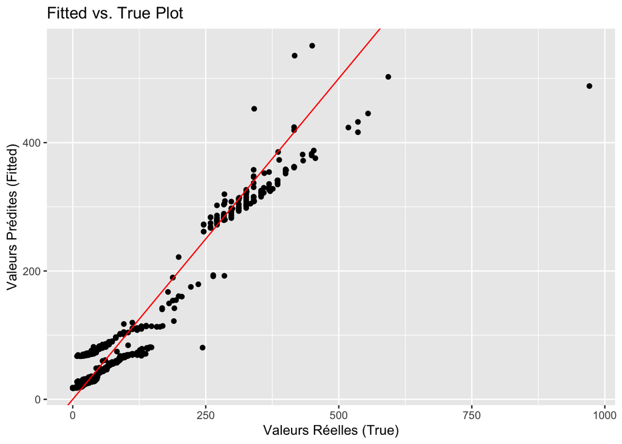